# Case study: How to scare people with a lab report

Wednesday, June 24, 2026

**NoteToday: Wednesday June 24**

**Before class**

- Nothing to read. Bring your skepticism.

**Plan for today**

- A real news story: **“there’s a cancer chemical in your sunscreen.”**
- We’ll tell it the way the headlines did — then take it apart.
- The point isn’t chemistry. It’s how a **technically true measurement** becomes a **scary, misleading claim**, why it **spread unchecked**, and how a data person spots the move.
- Short activity: you debunk one.

**Helpful links**

- Source: [Lab Muffin — *Bad Science: Valisure keeps finding cancer chemicals in your products*](https://labmuffin.com/bad-science-valisure-keeps-finding-cancer-chemicals-in-your-products/) · Lab Muffin / *theecowell* podcast with toxicologist **Lyle Burgoon, PhD** and chemist **Michelle Wong, PhD**
- Syllabus · Schedule

# Act I — the story, as you’d hear it

## A headline lands

In 2024, an independent testing lab announced it had found **benzene** — *a known human carcinogen* — in popular **benzoyl peroxide** acne creams (Proactiv, Clearasil, CeraVe, and more).

It was not the first time. The same lab had already flagged benzene in:

| Year | Product |
| --- | --- |
| 2021 | Hand sanitizer |
| 2021 | Sunscreen |
| 2021 | Body spray & antiperspirant |
| 2022 | Dry shampoo |
| 2024 | Benzoyl peroxide acne treatment |

The internet did what the internet does. One creator summed up the mood:

> “We are literally rubbing **cancer** into our skin.”

**The New York Times:** *“This Carcinogen Keeps Cropping Up in Personal Care Products.”*

## What even is benzene?

A fair question to ask before panicking.

- One of the most recognizable molecules in chemistry — the classic **hexagonal ring**.
- Produced whenever carbon-based material **burns incompletely**: fuel combustion, wildfires, cigarette smoke. A trace contaminant in petroleum.
- **It is everywhere.** Gasoline is **~1% benzene**. Your biggest everyday exposures are things like **pumping gas** and **parking a car in an attached garage** — not your moisturizer.

Hold onto that last point. We’ll come back to “compared to what?”

## Who’s making the claim?

This is the part that makes it land. The source is **not** a random influencer. It’s **Valisure**, and on paper they look impeccable:

- An **independent analytical lab** — not affiliated with any government agency.
- Their reputation rests on a **track record**: around 2018 they reported a carcinogen (NDMA) in the heartburn drug **ranitidine (Zantac)** — which then got **pulled from the market**.
- They file formal **FDA Citizen Petitions** — official regulatory documents.
- The benzoyl peroxide petition lists **two PhD scientists** as authors.
- They prominently advertise their **ISO accreditation**.
- They cite the **FDA’s own 2 ppm limit**, peer-reviewed toxicology, and a top UC Berkeley benzene expert.

Independent. Accredited. Published. Carcinogen. FDA limits. This *sounds* airtight.

## The scary numbers

**Important**

Benzene is a **Group 1 carcinogen** (the same category as tobacco smoke and asbestos). It causes leukemia. There is no argument about that part.

## So… should you panic?

Put yourself in the reader’s chair. You’ve got:

- ✅ An independent, accredited lab with a track record
- ✅ A genuine, no-kidding human carcinogen
- ✅ Official-looking documents citing the FDA’s own limits
- ✅ Huge multipliers — *50,000 times* the limit
- ✅ “No safe level”

Every individual fact above is **true**. Throw out the sunscreen?

. . .

Hold on. We’re a data class. Let’s put the hat on.

# Act II — now read it like a data scientist

## The one question that breaks the spell

**Tip**

**Compared to what?**

Every alarming number above is a number *without a denominator, without comparable units, or without the conditions it was measured under.*

A measurement is not a claim. The claim is built on top of the measurement. Let’s find each move.

## Red flag 1 — the conditions were rigged

To get benzene *out* of benzoyl peroxide, you have to **break the molecule down**. That takes heat. So how was it tested? They heated the products and called it “real-world conditions.” It isn’t:

| Temp | Valisure’s story | Reality |
| --- | --- | --- |
| 40 °C | “a hot bathroom during a shower” | got it by **misreading a graph** — read the *humidity* line against the *temperature* axis; sustained for a long time in a near-airtight room |
| 50 °C | “reasonable during distribution” | a **stress-test** temp; the int’l standard is 40 °C |
| 70 °C | “a hot car” | the cited paper’s readings were mostly **50–60 °C**; a car this hot, sustained ~2 weeks, benzene sealed inside |

**Warning**

This is **accelerated aging** — a legitimate tool for *finding* a failure mode. It is not a model of Tuesday on your bathroom shelf. At 70 °C the packaging physically **ruptured** after a week.

## Red flag 1, continued — the missing number

Here’s the tell. In earlier petitions, Valisure published detailed benzene tables at **lower** temperatures. For benzoyl peroxide, they showed graphs at elevated temperatures but **quietly omitted the specific room-temperature numbers.**

> When someone reports the result from the most extreme condition and leaves out the ordinary one, that’s not an oversight. That’s **selective reporting** — a headline you’ll meet again in your own analyses.

The honest version of a finding includes the conditions *and* the boring baseline.

## Red flag 2 — the units are doing tricks

Two separate unit games inflate the numbers:

1. **ppm → ppb.** They slide between **parts per million** and **parts per *billion***. Same quantity, number looks **1,000× bigger.** Hard to read as accidental.
2. **ppm in air ≠ ppm in liquid.** In **air**, ppm is measured **by volume**; in a **liquid**, by **mass**. Valisure compared the allowable ppm *in air* to ppm measured *in a product* and called the product dangerous because the number was higher.

**Note**

“There are 20 ppm of benzene in this tube” tells you nothing about your exposure until you ask: *how much of the tube do you use, and how much gets in?*

## Red flag 3 — concentration vs. dose

This is the heart of it. **The dose makes the poison.** Two things drive your actual dose:

- **How much product?** A heavy sunscreen user applies maybe **2 shot glasses** a day; acne cream, ~0.75 g. You **breathe ~15,500 L of air** a day.
- **How much gets absorbed?** Skin absorbs **< 1%** of benzene. Lungs absorb **~50%**.

A scary *concentration* in a tiny dab of cream, barely absorbed through skin, is a completely different thing from the same concentration in the air you inhale all day. **The exposure scenarios aren’t close — but they’re presented as if they are.**

When you redo the “50,000×” comparison correcting for **dose** (concentration × amount used), it collapses:

## Red flag 3 — what the corrected numbers look like

```r
benzene <- tribble(
  ~product,            ~headline_multiple, ~dose_corrected_multiple,
  "Hand sanitizer",     50000,              22.0,
  "Sunscreen",          20000,               7.5,
  "Antiperspirant",     60000,               1.8,
  "Benzoyl peroxide",    1270,               0.9   # < 1 = LESS than ambient air
)
benzene
```

```
# A tibble: 4 × 3
  product          headline_multiple dose_corrected_multiple
  <chr>                        <dbl>                   <dbl>
1 Hand sanitizer               50000                    22
2 Sunscreen                    20000                     7.5
3 Antiperspirant               60000                     1.8
4 Benzoyl peroxide              1270                     0.9
```

Dose-corrected, the benzoyl peroxide exposure is actually **lower than the benzene you breathe from ordinary outdoor air.**

## Red flag 3 — the same data, drawn honestly

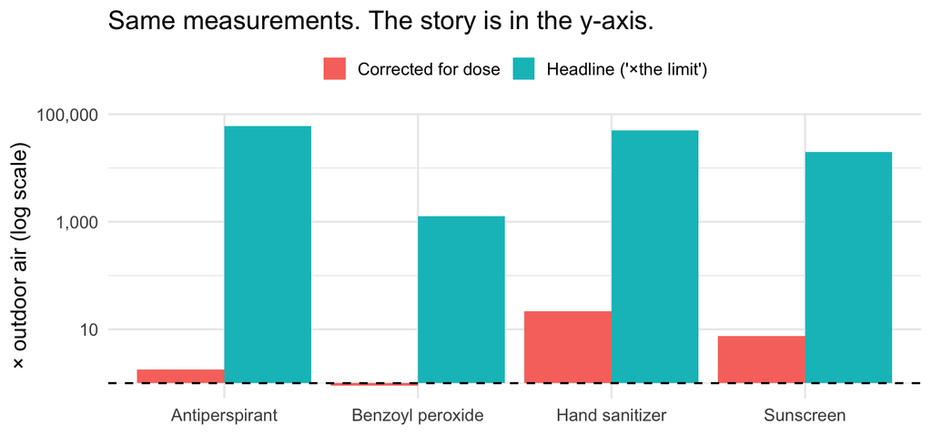

```r
benzene |>
  pivot_longer(-product, names_to = "version", values_to = "multiple") |>
  mutate(version = recode(version,
                          headline_multiple      = "Headline ('×the limit')",
                          dose_corrected_multiple = "Corrected for dose")) |>
  ggplot(aes(product, multiple, fill = version)) +
  geom_col(position = "dodge") +
  geom_hline(yintercept = 1, linetype = "dashed") +
  scale_y_log10(labels = scales::comma) +
  labs(x = NULL, y = "× outdoor air (log scale)", fill = NULL,
       title = "Same measurements. The story is in the y-axis.") +
  theme(legend.position = "top")
```

Note the **log scale** — without it the corrected bars vanish next to the headline. *How you draw it is part of the argument.*

## Red flag 4 — scary words, used loosely

Two phrases do most of the emotional lifting. Both are real and routinely misused.

**“Known human carcinogen” (Group 1)** = the *evidence it can cause cancer* is solid. It says **nothing about dose** — you need a high enough exposure for long enough. Also Group 1:

> sunlight · alcohol · processed meat · wood dust

**“No safe level / no safe dose”** is a **policy/regulatory** statement, not a biological fact. Being exposed to a molecule or two of benzene won’t hurt you; small doses appear fine. It means “we won’t *certify* any amount as risk-free,” so the limit stays conservative. **Detectable ≠ dangerous** — especially now that instruments detect almost anything.

## Red flag 4 — so what’s the actual risk?

Take the worst-case *honest* estimate for benzoyl peroxide — highest benzene level, daily use from birth to age 78, *assuming full absorption* (a wild overestimate):

**Note**

**≈ 8 extra cancers per 1,000,000 people** over a lifetime (0.0008%).

For scale:

- Baseline lifetime cancer risk: **~1 in 2** (men), **~1 in 3** (women).
- Cooking one meal on a **gas stove**: ~100 µg benzene.
- 5 minutes **pumping gas**: 9–306 µg inhaled.

The expert Valisure *quotes* for “no safe level,” toxicologist Martyn Smith:

> “I don’t like downplaying public health risks, but I also don’t like scaring the public unnecessarily when there’s no need for that.”

# Act III — why did dodgy science spread unchecked?

## A pattern, not a one-off

Benzene wasn’t the first time. The track record from Act I looks different up close:

- **Zantac (ranitidine), ~2018.** The carcinogen finding caused a media frenzy and the drug was pulled — replaced with **less effective** alternatives. When the FDA tried to **replicate** it, the result only appeared when the drug was **heated until it charred** from white to black. Not relevant to how anyone takes it.
- **Metformin (diabetes).** Similar alarm. FDA + global regulators again found the **methods flawed**: their instrument (LC-MS) reads compounds as **peaks**, and **two overlapping peaks were counted as one big peak** — making it look like far more carcinogen was present than really was.

**Important**

The “track record” that made them credible in Act I was itself **a string of findings the FDA could not reproduce.**

## The credibility was mostly costume

Look again at what made them sound authoritative — each marker is hollower than it seems:

| Sounds like proof | What it actually means |
| --- | --- |
| **“ISO accredited”** | The lab met a standard *at audit time*. It does **not** certify that every method they use is valid, or that a given analysis is even **in scope**. |
| **“Published findings”** | Most benzene results first appeared **on their own website** — *science by press release.* Some reached journals later, helped by institutional ties. |
| **“Independent lab”** | True they’re not government. They also have **close ties to class-action lawyers** — who profit from exactly these alarms. |

Credentials are a *starting* question, not a *final* answer.

## Authority ≠ expertise in the right field

Why did doctors repeat it? Some dermatologists were literally **phoning patients** about benzene in their sunscreen and acne cream.

- Valisure’s data were platformed at the **AAD** (American Academy of Dermatology) conference via **Dr. Chris Bunick** — a dermatologist, editor-in-chief of *Dermatology Times*, **and** a co-author on Valisure papers.
- When someone with that standing presents “breaking news” at a major conference, **it carries weight.**

**Warning**

But the appraisal this needed is in **analytical chemistry and toxicology** — not a dermatologist’s home turf. Real expertise, **wrong field.** Platformed by the AAD, the claims sailed through unchallenged.

## And the media did the rest

- A **Bloomberg** journalist repeatedly reported the findings; several people at the lab have **Yale** ties — borrowed credibility, claims taken at face value.
- The coverage rule, unchanged for a century:

**Tip**

**“If it bleeds, it leads.”** A calm “your sunscreen is fine, actually” doesn’t trend. “Cancer in your sunscreen” does.

This is the “unchecked” part: accreditation, an authority figure, a prestige outlet, and an attention-driven feed — each *assumed someone else had checked the chemistry.* No one had.

## The myth of “peer-reviewed = true”

Suppose the benzene work *had* all been peer-reviewed. Would that settle it? No.

> **Andrew Wakefield’s 1998 anti-MMR-vaccine paper** was peer-reviewed and published in *The Lancet*, one of the most prestigious journals in medicine. It was later **fully retracted** and its conclusions discredited — but only after fueling years of vaccine fear that still costs lives.

**Note**

Peer review is an **oversight step, not a guarantee.** And **no single study = truth.** Confidence comes from **many** independent groups finding the same thing with **different methods**. One lab, one petition, one conference talk is where a question *starts* — not where it ends.

# Act IV — the takeaways

## How to make a true measurement lie

Strip away the chemistry and you have a **reusable recipe.** You’ll see every step again — in marketing, a viral chart, maybe a draft of your own project:

1. **Start with a real measurement.** Credibility comes free.
2. **Pick the extreme condition,** report it, omit the baseline. *(selective reporting)*
3. **Switch units** (ppm→ppb) and **compare mismatched ones** (air vs. liquid) so the multiplier balloons.
4. **Report concentration, never dose.** *(missing denominator)*
5. **Wrap it in loaded words** — “carcinogen,” “no safe dose,” “toxic.”
6. **Lead with the relative number** (“50,000×”), bury the absolute one (“8 in a million”).
7. **Borrow authority** — accreditation, a credentialed messenger, a prestige outlet — and let everyone assume someone else checked.

None of this requires lying. That’s what makes it work.

## Honest debunking includes its own doubts

One more thing — notice what the *debunkers* do that Valisure didn’t:

> In **March 2025** the FDA said it had found an issue and would publish in a peer-reviewed journal. As of now it **hasn’t appeared** (likely amid broader FDA disruption). Based on past investigations, Valisure’s benzene measurements are **probably** also flawed — but we’re **still waiting on confirmation.** They don’t look reliable; the full extent is **still unclear.**

**Tip**

The careful version says *“probably,” “still unclear,” “waiting on confirmation.”* Certainty is easy to sell. **Calibrated uncertainty is the honest product** — and it’s what we want in your project conclusions too.

## Your toolkit, five questions

When a number is meant to scare or sell you, ask:

**Tip**

1. **Compared to what?** (denominator, baseline, units)
2. **What’s the dose?** (concentration ≠ exposure)
3. **Under what conditions** was it measured?
4. **Relative or absolute?** (“50,000×” vs. “8 in a million”)
5. **Who says so — and who benefits** if I believe it? (and *is this their field?*)

Aim these at **your own** project analysis before someone aims them at you.

## Why it matters (briefly)

Without the sermon:

- **Incentives exist.** Labs that find alarming things get attention, petitions, and lawsuit business; media gets clicks. Notice incentives; you needn’t assume malice.
- **There’s real harm downstream.** People stopped using **sunscreen** and effective **acne treatment** over a hypothetical micro-risk — trading it for real ones.
- **It burns trust.** Every overblown alarm makes the *next, genuine* warning easier to ignore.

The skill we’re practicing cures both panic *and* cynicism: not “ignore experts,” but **read the claim like data.**

# Activity

## In-class activity (~20 min)

In groups of 2–3. I’ll hand each group a **real** scary health/product headline (or pick one from your own feed).

**Produce a one-paragraph “debunk-or-confirm”:**

1. What is the **actual measurement** under the headline?
2. Which **recipe step(s)** is it using? (extreme condition? unit switch? concentration-not-dose? loaded words? relative-not-absolute? borrowed authority?)
3. What **single question** would most quickly deflate or confirm it?
4. Verdict: **real but oversold**, actually **nothing**, or **legitimately alarming**?

Bonus (R): take the `benzene` tibble and make one chart that looks **terrifying** and one that looks **trivial** — using the *same numbers.* What did you change?

## Wrap-up & looking ahead

**What we covered**

- A **measurement** is not a **claim** — the claim is built on top of it.
- The recipe: real number → extreme condition → unit games → concentration-not-dose → loaded words → relative-not-absolute → **borrowed authority.**
- It spread because accreditation, a credentialed messenger, prestige media, and “if it bleeds it leads” each assumed *someone else checked.*
- Peer review and credentials are **oversight, not proof**; truth is **cumulative.**
- The fix is one habit: **“compared to what?”** — give your own project that same scrutiny.

**Upcoming**

- **Thu Jun 25:** project work day · oral check-in #2
- **Fri Jun 26:** Quiz 6 · short presentations · wrap-up
- **Final report + video due Fri 11:59 p.m.**

**Reach out**

Stuck? Office hours, or email me (cgc5478@psu.edu) or Xinyue (xpw5228@psu.edu).

**Reference**

- [Lab Muffin debunk (full article)](https://labmuffin.com/bad-science-valisure-keeps-finding-cancer-chemicals-in-your-products/)
- Lab Muffin / *theecowell* podcast w/ Lyle Burgoon, PhD & Michelle Wong, PhD
- Syllabus · Schedule